# Determining temperature from frequencies

## Temperature estimation from the measurement of the frequencies of specific vibrational modes

*Ab initio* computed vibrational frequencies of a mineral, at different cell volumes, are used for temperature estimation of a *body* whose IR spectrum has been recorded, within the framework of the *Quasi-Harmonic Approximation* (**QHA**)

It is advised to follow the tutorials *Basic Eos* and *Dealing with the frequencies* to learn the basics of the package usage.

The first command assures that graphical output is plot directly in the notebook:

```python
%matplotlib inline
```

Start the program in the notebook. The example refers to the case of pyrope, for which a folder containing all the required *ab initio* data (static energies and frequencies as function of the unit cell volume) must be present, together with an *input.txt* file:

```python
%run bm3_thermal_2.py
```

```
File quick_start.txt found in the master folder
Input files in 'pyrope' folder

Input file

STATIC
pyrope_static.dat
VOLUME
volume.dat
FREQ
pyrope_freq_2.dat
EXP
experimental.txt
FITVOL
POLY
725. 773. 16  3
FU
4 20
SET
0 1 4 5 8 10 15 21
CP
0. 2 -2. -1 -0.5
ALPHA
0. 2 -2  -1 -0.5
END

-------- End of input file -------


Static BM3 EoS

Bulk Modulus: 173.95 (0.06) GPa
Kp:             4.30 (0.03)
V0:           756.1932 (0.00) A^3
```

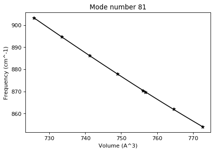

```python
check_poly(81)
```

To check for consistency of the ab initio data, compute the equation of state at 300K (3^rd order Birch-Murnaghan EoS), and compare the result with the experimental bulk modulus:

```python
eos_temp(300, prt=False)
```

```
 ** BM3 fit **

EoS at the temperature of 300.00 K

Bulk Modulus: 159.97   (0.08) GPa
Kp:             4.67   (0.02)
V0:           767.6963 (0.004) A^3

Fix status: False
Fit of frequencies is active
Polynomial fit: degree  3
Volume range: 725.00 - 773.00, points=16
```

For subsequent computations it is advised to keep Kp fixed to the values optimized at 300K (Kp = 4.67)

```python
set_fix(4.67)
```

The current settings can be printed at any time by using the **info.show** command:

```python
info.show()
```

```
Current settings and results

Static data            ** min, max volumes: 725.7483, 772.6196; points: 8
Frequency volume range ** min, max volumes: 725.7483, 772.6196; points: 22
Selected freq. sets    ** min, max volumes: 725.7483, 772.6196; points: 8
Frequency sets:           [0, 1, 4, 5, 8, 10, 15, 21]

Fit of frequencies     ** type: poly, degree: 3
                          min, max volumes: 725.0000, 773.0000; points 16

** Static EoS (BM3) **
K0: 173.95 GPa, Kp: 4.30, V0: 756.1932 A^3

** BM3 EoS from the last computation, at the temperature of 300.00 K **
K0: 159.97 GPa, Kp: 4.67, V0: 767.6963 A^3
Kp fixed

No excluded modes

Kieffer model off
```

Within the limits of **QHA**, frequencies do change with T due to thermal expansion: as T increases, the cell volume also increases (*generally*) and frequencies change accordingly as an effect of the volume variation. Check the thermal expansion at 300K, by using the command **thermal_exp_p**; to have a description of this command, just type:

```python
help(thermal_exp_p)
```

```
Help on function thermal_exp_p in module __main__:

thermal_exp_p(tt, pp, plot=False, exit=False, **kwargs)
    Thermal expansion at given temperature and pressure

    Args:
        tt:               temperature
        pp:               pressure
        plot (optional):  plots pressure vs T values (see help to
                          the thermal_exp_v function)
    **kwargs:
        fix: if fix is provided, it controls (and overrides the setting
             possibly chosen by set_fix) the optimization of kp in BM3;
             if fix > 0.1, kp = fix and it is not optimized.

    Note: see help for the thermal_exp_v function
```

```python
thermal_exp_p(300,0)
```

```
Thermal expansion: 3.24e-05 K^-1
Bulk modulus:        159.96 GPa
Pressure:              0.00 GPa
Volume:              767.6964 A^3
```

```python
help(freq_poly_p)
```

```
Help on function freq_poly_p in module __main__:

freq_poly_p(ifr, tt=300.0, p0=0.0, plot=True, prt=True, **kwargs)
    Prints the frequency of a given mode at some temperature
    and pressure if a spline fitting method has been chosen

    Args:
        ifr: mode number (starting from 0)
        tt: temperature (K)
        pp: pressure (GPa)

    kwargs:
        fix (optional): Kp value fixed to *fix* if *fix* > 0.1

    A polynomial fitting must be active
```

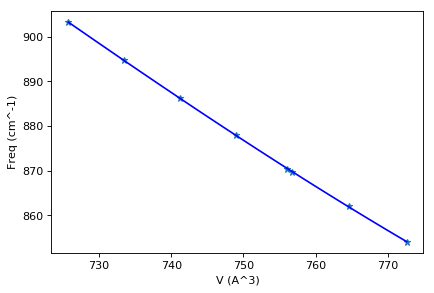

```
Frequency: 858.86 cm^-1
Pressure 0.00 GPa, temperature 300.00 K, volume 767.6964 A^3
```

```python
freq_poly_p(81, 300, 0)
```

So, the frequency of that mode, at T=300K (and P=0 GPa) is 858.86 cm^-1. To check the reliability of the code and the possible error on the temperature estimation due to the fits, use the function **temperature_freq**, whose description is:

```python
help(temperature_freq)
```

```
Help on function temperature_freq in module __main__:

temperature_freq(ifr, freq, tmin, tmax, npt, pp, degree=2, **kwargs)
    Computes the temperature given the frequency of a normal mode, at a fixed
    pressure. A T range must be specified

    Args:
        ifr:               normal mode number
        freq:              value of the frequency
        tmin:              minimum value of T
        tmax:              maximum value of T
        npt:               number of T points in the range
        pp:                pressure
        degree (optional): degree of the polynomial fitting the P/freq
                           values from the pressure_freq_list function

    **kwargs:
        fix: Kp fixed, if fix=Kp > 0.1

    Note: it is advised to keep Kp fixed by either specifying fix, or
          by using set_fix.
          For "noisy" modes, use polynomial fits (set_poly), or
          a spline fit (set_spline) with a large smooth parameter.
```

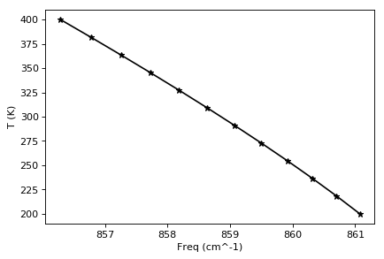

```
Temperature: 299.93 K
Mode: 81, frequency: 858.86 cm^-1, Pressure:   0.00 GPa
```

```python
temperature_freq(81, 858.86, 200, 400, 12, 0, degree=3)
```

Suppose that the value of the measured frequency is 855.5 cm^-1; the temperature estimation is:

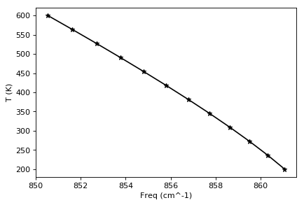

```
Temperature: 429.36 K
Mode: 81, frequency: 855.50 cm^-1, Pressure:   0.00 GPa
```

```python
temperature_freq(81, 855.5, 200, 600, 12, 0, degree=3)
```